# Interactions Between Collared and Not Collared White-Tailed Deer in Staten Island

2026-04-13

Libraries

```r
library(tidyverse)
```

```r
library(ggplot2)
library(stringr)
library(dplyr)
```

import files

```r
deer <- read.csv("images_2009855.csv")
cameras <- read.csv("deployments.csv")
```

Data cleaning and prep

```r
deerOnly <- filter(deer, common_name == "White-tailed Deer")

#only take the useful columns to reduce the load on my computer
deerReduced <- deerOnly %>% dplyr::select(deployment_id, image_id, filename, identified_by, common_name, timestamp, number_of_objects, individual_id, behavior, highlighted, markings)

cameraReduced <- cameras %>% dplyr::select(deployment_id, subproject_name, latitude, longitude, placename, camera_name)

#remove the BLK pictures
noBLK <- deerReduced %>% filter(grepl("BLK", behavior) == FALSE)

#merge datasets together based on the camera id
deerCoord <- noBLK %>% left_join(cameraReduced, by = "deployment_id")

#add interaction column and preset to 0
deerCoord$interaction <- 0


#remove NA's
deerCoord <- na.omit(deerCoord)
```

Data fixing from older rmd file

```r
#creating a flag column to flag those with error for review
deerCoord$Flag <- 0

#extract the assumed correct id from the markings column and put it all in a list
ids = c()
for(x in 1:nrow(deerCoord)) {
  #take out each id using regex
  curr <- str_extract_all(deerCoord$markings[x], "\\d+(?:-[A-Z]+)?")[[1]]
  if(length(curr) == 0) {
    ids[x] <- NA #no numbered id found
  } else {
    ids[x] <- paste(curr, collapse = ",") #paste together the ids with "," if more than one found, if only 1 this does not add a comma
  }
}

#if an issue is found it will fix it then flag it with a 1 for review
for(x in 1:nrow(deerCoord))
{
  #fixing the count number, it will based the count based on the annotation commas
  if (deerCoord$number_of_objects[x] != (str_count(deerCoord$markings[x], ",")+ 1))
  {
    deerCoord$number_of_objects[x] <- (str_count(deerCoord$markings[x], ",")+ 1)
    deerCoord$Flag[x] = 1
  }
  #if id column doesn't match it will update with the id from the markings column
  if(!is.na(ids[x]) && !is.na(deerCoord$individual_id[x]) &&(ids[x] !=   deerCoord$individual_id[x])) #ignoring the NAs
  {
    deerCoord$individual_id[x] <- ids[x]
    deerCoord$Flag[x] = 1
  }
}
```

Removing bursts

```r
#only take one row if all the following column values are the same in multiple rows
deerDistinct <- deerCoord %>% distinct(timestamp, markings, behavior, deployment_id, subproject_name, .keep_all = TRUE)
View(deerDistinct)
```

Finding interactions of all combinations

```r
#finding direct interactions
for(x in 1:nrow(deerDistinct))
{
  if(grepl(",", deerDistinct$markings[x])) #only proceed if there is more than 1 deer in a picture
  {
      #split up the markings column by ,
      curr <- strsplit(deerDistinct$markings[x], ",")[[1]]
      #the regex means only take the things between the first _ and the next _
      middle <- str_match(curr,"^[^_]*_([^_]*)_.*$")[,2]
      collar <- sub("_.*", "", curr) #take anything before the first _ from curr

      #based on assumption that all collared deer are tagged
      #finding the tagged and not tagged from the curr list
      NT <- any(middle == "NT", na.rm = T) #if any item is NT this will return true
      numTag <- sum(middle != "NT" & middle != ".", na.rm = T) #return # of tagged deer
      numCol <- sum(collar == "C", na.rm = T)#return # of collared deer
      numNoCol <- sum(collar == "NC", na.rm = T)#return # of uncollared deer
      NCTag <- sum(collar == "NC" & (middle != "NT" & middle != "."), na.rm = TRUE)#of NC Tagged
      NCNT <- sum(collar == "NC" & middle == "NT", na.rm = TRUE) #return # of NC NT deer


      #if C+c that actually means 2+ collared deer
      if (numCol > 1 && NCTag > 0 && NCNT > 0)#C + C + (NC & T) + (NC & NT)
      {
        deerDistinct$interaction[x] = 6
      }
        else if(numCol > 1 && NCTag > 0) #C + C + (NC & T)
      {
        deerDistinct$interaction[x] = 1
      }
      else if (numCol > 1 && NCNT > 0) #C + C + (NC & NT)
      {
        deerDistinct$interaction[x] = 2
      }
      else if (numCol > 1 && numNoCol == 0) #C + C
      {
        deerDistinct$interaction[x] = 3
      }
      else if (numCol == 1 && NCTag > 0)#C + (NC & T)
      {
        deerDistinct$interaction[x] = 4
      }
      else if (numCol == 1 && NCNT > 0) #C + (NC & NT)
      {
        deerDistinct$interaction[x] = 5
      }
  }
}
```

Seperate the interactions / solo deer

```r
intOnly <- deerDistinct %>% filter(interaction > 0)
NoIntDeer <- deerDistinct %>% filter(interaction == 0)
```

Using time intervals to find the exact number of interactions

If no interaction for 3+ minutes after the series of photos interactions then everything before is counted as 1 interaction.

**3 minutes** **4 & 5 minutes** 4 and 5 gave the same result, but tiny increase of interactions from 3 mins **1 minutes** slight increase in interactions from 3 minutes

**Test out other times by changing the 180 to a different number, all times in seconds**

```r
library(dplyr)

#only keep the interactions and group them
deerOrganized <- intOnly %>% arrange(deployment_id, interaction, timestamp) %>% group_by(deployment_id, interaction)

deerInterval <- deerOrganized %>% mutate(
                prevTime = lag(timestamp), #lag = take previous
                prevMark = lag(markings), #take the previous of time and markings

                #calculate the time different between the current and previous photos for all
                difTime = as.numeric(difftime(timestamp, prevTime, units = "secs")),
                #if the time is na or the marking has changed or the time is over 3 minutes then it is true its a new interaction
                #the na is because lag assigns the first "lagged row" to NA since there is nothing before the first row
                newInt = ifelse(is.na(difTime) | markings != prevMark | difTime > 180, 1, 0),

                #makes a running total instead of just an overall total like sum()
                newEvent = cumsum(newInt)
) %>% ungroup() #ungroup since it is getting grouped differently below

View(deerInterval)

#add a new column to calculate the amount of time that specific interaction happened for
intTime3 <- deerInterval %>%
  group_by(deployment_id, newEvent, markings) %>%
  mutate(
    startTime = min(timestamp), #get the start time which will always be the smallest in each group so using min()
    endTime   = max(timestamp),
    #as.numeric gets rid of the "secs" at the end
    interactTime = as.numeric(difftime(endTime, startTime, units = "secs"))
  )


#only keep one row from each group of interactions,
#at this point time the original timestamp column is only really relevant for the interactions that only had a single picture (interactTime == 0) since the way it keeps rows is by pulling the first item from each group
intervalDistinct3 <- intTime3 %>% distinct(endTime, startTime, newEvent, interactTime, interaction, deployment_id, markings, .keep_all = T)

# 0 means there was a single photo of the interaction, but that does not make sense for an interaction to last 0 seconds, and the amount of zeroes can potentially cause problems in the code later on
intervalDistinct3$interactTime[intervalDistinct3$interactTime == 0] <- 1

View(intervalDistinct3)
```

Different because of time being exceeded:

```r
timeEx <- deerOrganized %>% mutate(
                prevTime = lag(timestamp), #lag = take previous
                prevMark = lag(markings), #take the previous of time and markings

                difTime = as.numeric(difftime(timestamp, prevTime, units = "secs")),
                #if the time is na or the marking has changed or the time is over 3 minutes then it is true its a new interaction
                newInt = ifelse(is.na(difTime) | difTime > 180, 1, 0),

                newEvent = cumsum(newInt)
) %>% ungroup() #ungroup since it is getting grouped differently below

intTimetime <- timeEx %>%
  group_by(deployment_id, newEvent, markings) %>%
  mutate(
    startTime = min(timestamp),
    endTime   = max(timestamp),
    #as.numeric gets rid of the "secs" at the end
    interactTime = as.numeric(difftime(endTime, startTime, units = "secs"))
  )

timeExceed <- intTimetime %>% distinct(endTime, startTime, newEvent, interactTime, interaction, deployment_id, markings, .keep_all = T)

View(timeExceed)
```

new interaction bcz of id changes:

```r
deerIntervalID <- deerOrganized %>% mutate(
                prevTime = lag(timestamp), #lag = take previous
                prevMark = lag(markings), #take the previous of time and markings

                difTime = as.numeric(difftime(timestamp, prevTime, units = "secs")),
                newInt = ifelse(is.na(difTime) | markings != prevMark, 1, 0),

                newEvent = cumsum(newInt)
) %>% ungroup() #ungroup since it is getting grouped differently below

intTimeID <- deerIntervalID %>%
  group_by(deployment_id, newEvent, markings) %>%
  mutate(
    startTime = min(timestamp),
    endTime   = max(timestamp),
    interactTime = as.numeric(difftime(endTime, startTime, units = "secs"))
  )

idChange <- intTimeID %>% distinct(endTime, startTime, newEvent, interactTime, interaction, deployment_id, markings, .keep_all = T)

View(idChange)
```

Making separate datasets for each type of interaction This will show how much the deer interact, the more pictures of them together the more they are interacting.

```r
#making separate datasets for each type of interactions
CCNcT <- intervalDistinct3 %>% filter(interaction == 1)
CCNcNt <- intervalDistinct3 %>% filter(interaction == 2)
CC <- intervalDistinct3 %>% filter(interaction == 3)
CNcT <- intervalDistinct3 %>% filter(interaction == 4)
CNcNt <- intervalDistinct3 %>% filter(interaction == 5)
CCNcNtNcT <- intervalDistinct3 %>% filter(interaction == 6)
```

Number of interactions per tagged deer

```r
library(dplyr)
#split the ids by comma into separate rows
deerTally <- intervalDistinct3 %>% separate_rows(individual_id, sep = ",") %>%
  group_by(individual_id) %>%#group by id so the summarize can combine it by id
  mutate(individual_id = trimws(individual_id)) %>% #get rid of any whitespace that slipped into the id section
  filter(individual_id != "") %>% #it counted all the rows without ids as a blank id and gave it its own row so this gets rid of it
  summarise(#keep a tally of how many times each id has each interaction
    int1 = sum(interaction == 1),
    int2 = sum(interaction == 2),
    int3 = sum(interaction == 3),
    int4 = sum(interaction == 4),
    int5 = sum(interaction == 5),
    int6 = sum(interaction == 6),
    totalInts = int1 + int2 + int3 + int4 + int5 + int6,#get the total number of interactions
    totalTime = sum(interactTime), #total length of time that deer spent
  )
View(deerTally)
```

**EDA** percentages of each type of interaction

```r
#only 2.8% of interaction images show C + C + NC_T deer interacting
nrow(CCNcT) / nrow(intervalDistinct3)
```

```
## [1] 0.0284495
```

```r
#only 10.2% of interaction images show C + C + NC_NT deer interacting
nrow(CCNcNt) / nrow(intervalDistinct3)
```

```
## [1] 0.1024182
```

```r
#only 11.4% of interaction images show 2+ collared deer interacting (no NC deer present)
nrow(CC) / nrow(intervalDistinct3)
```

```
## [1] 0.113798
```

```r
#31.6% of interaction images show C + NC_T deer interacting
nrow(CNcT) / nrow(intervalDistinct3)
```

```
## [1] 0.3157895
```

```r
#43.8% of interaction images show c + NC_NT deer interacting
nrow(CNcNt) / nrow(intervalDistinct3)
```

```
## [1] 0.4381223
```

```r
#0.1% show C+c+ncnt+nct
nrow(CCNcNtNcT) / nrow(intervalDistinct3)
```

```
## [1] 0.001422475
```

bar plot for number of each type of interation

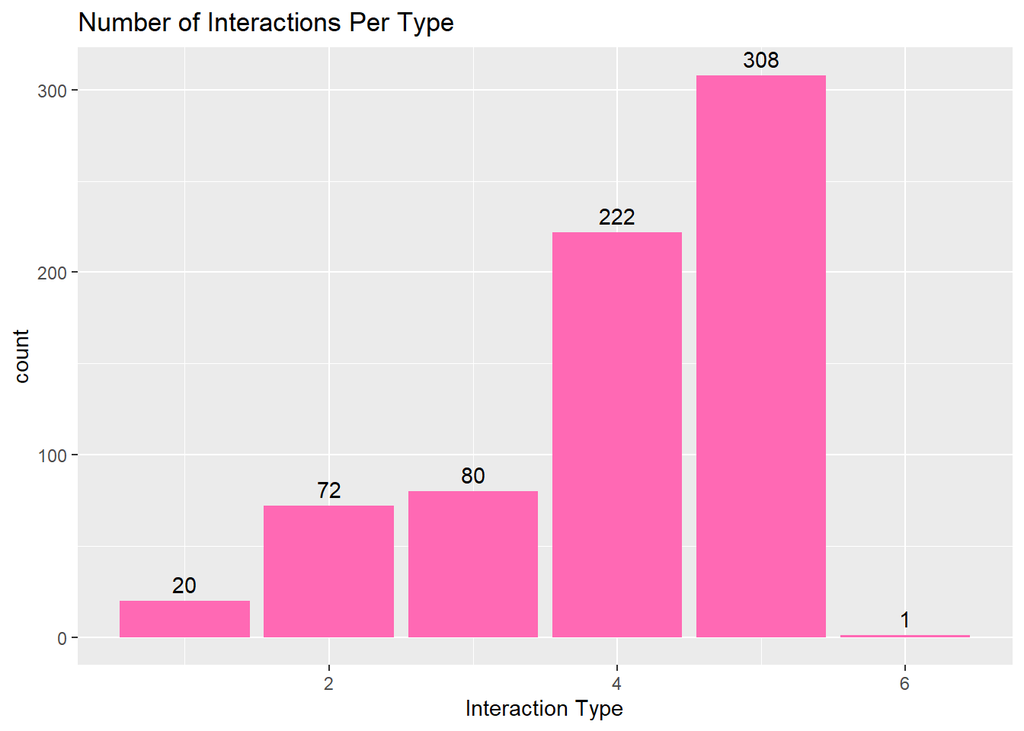

```r
ggplot(intervalDistinct3, aes(interaction)) +
  geom_bar(fill="hotpink") +
  geom_text(stat = "count", aes(label = after_stat(count), vjust = -0.5)) +
  labs(title = "Number of Interactions Per Type", x = "Interaction Type")
```

histogram for druation of interaction

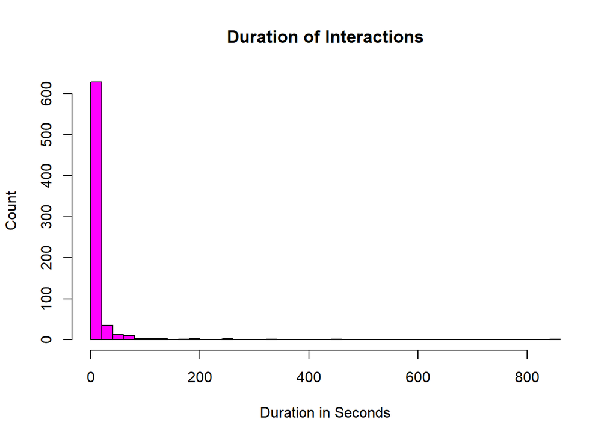

```r
hist(intervalDistinct3$interactTime, breaks = 50, main = "Duration of Interactions", xlab = "Duration in Seconds", ylab = "Count", col = "magenta")
```

data prep for poisson for gender vs seasons for interaction duration

```r
#does gender or season effect interactions more?

#update dataset with counts grouped by M/F and season(pulled from the date not the subproject_name)

#find the chaarcter after the last _ and put it in a list
intervalDistinct3$gender <- sapply(strsplit(intervalDistinct3$markings, ","), function(x) {
  paste(sub(".*_", "", x), collapse = ",")
})


#unfortunately found an issue of interactions missing the last underscore and therefore having no written gender
for(x in 1:nrow(intervalDistinct3))
{
  curr <- strsplit(intervalDistinct3$gender[x], ",")[[1]] #split the cell
  fixedLine <- sapply(curr, function(y) #if something other than LAD found in the split fix it
    {
    if(y %in% c("L", "A", "D"))
    {
      return(y)
    }
    if(grepl("OR|Y", y))
    {
      return("L")
    }
    if(grepl("WH", y))
    {
      return("A")
    }
  })
  #if a change had to be made flag it
  if(paste(fixedLine, collapse = ",") != intervalDistinct3$gender[x])
  {
    intervalDistinct3$Flag[x] <- 1
  }
  intervalDistinct3$gender[x] <- paste(fixedLine, collapse = ",") #put the fixed listback
}



#split and find all females/males/unknown sex
intervalDistinct3$female <- sapply(strsplit(intervalDistinct3$gender, ","), function(x)
  {
  sum(x == "L")
})
intervalDistinct3$unknown <- sapply(strsplit(intervalDistinct3$gender, ","), function(x)
  {
  sum(x == "D")
})
intervalDistinct3$male <- sapply(strsplit(intervalDistinct3$gender, ","), function(x)
  {
  sum(x == "A")
})

#extract the month
intervalDistinct3$season <- format(as.POSIXct(intervalDistinct3$timestamp), "%B")
#map the month to season
map <- c("January" = "Winter", "February" = "Winter", "March" = "Spring", "April" = "Spring", "May" = "Spring", "June" = "Summer", "July" = "Summer", "August" = "Summer", "September" = "Fall", "October" = "Fall", "November" = "Fall", "December" = "Winter")
intervalDistinct3$season <- map[intervalDistinct3$season]


View(intervalDistinct3)
```

negative binom for gender vs seasons for interaction duration

Proportion of female deers has a great effect on the length of interactions between C/NC While seasons have no significant effect.

https://stats.oarc.ucla.edu/r/dae/zinb/ <- explains why zero inflated negative binomial wouldnt work

```r
library(MASS)
#dont care about interaction = 3 bcz that is C+C exclusivly
ColNcOnly <- intervalDistinct3 %>% filter(interaction != 3) %>% mutate(Fproportion = female/number_of_objects)
View(ColNcOnly)

#regular glm showed sigficantly worse AIC at over 19k
#poisDF <- glm(interactTime ~ season + Fproportion, family = poisson, data = ColNcOnly)
#summary(poisDF)


#negative binomial improved the model signifcantly meaning we have a lot of over dispuersion

nbDF <- glm.nb(interactTime ~ season + Fproportion,
               data = ColNcOnly)
summary(nbDF)
```

```
##
## Call:
## glm.nb(formula = interactTime ~ season + Fproportion, data = ColNcOnly,
##     init.theta = 0.4755975244, link = log)
##
## Coefficients:
##              Estimate Std. Error z value Pr(>|z|)
## (Intercept)    1.6805     0.1451  11.578  < 2e-16 ***
## seasonSummer   0.2059     0.1858   1.108 0.267837
## seasonWinter   0.1099     0.2440   0.451 0.652345
## Fproportion    0.6834     0.1776   3.848 0.000119 ***
## ---
## Signif. codes:  0 '***' 0.001 '**' 0.01 '*' 0.05 '.' 0.1 ' ' 1
##
## (Dispersion parameter for Negative Binomial(0.4756) family taken to be 1)
##
##     Null deviance: 720.86  on 622  degrees of freedom
## Residual deviance: 702.87  on 619  degrees of freedom
## AIC: 3831.3
##
## Number of Fisher Scoring iterations: 1
##
##
##               Theta:  0.4756
##           Std. Err.:  0.0242
##
##  2 x log-likelihood:  -3821.3230
```

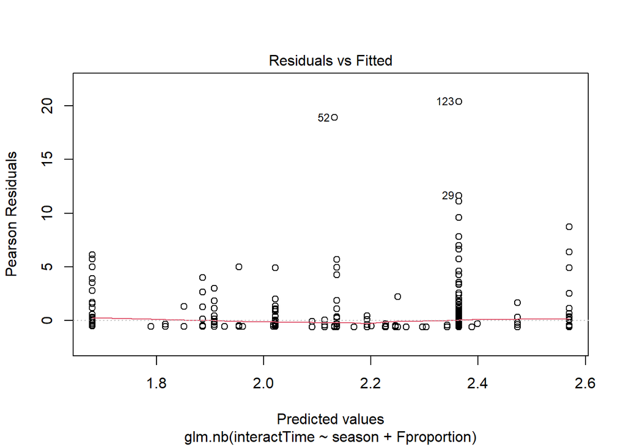

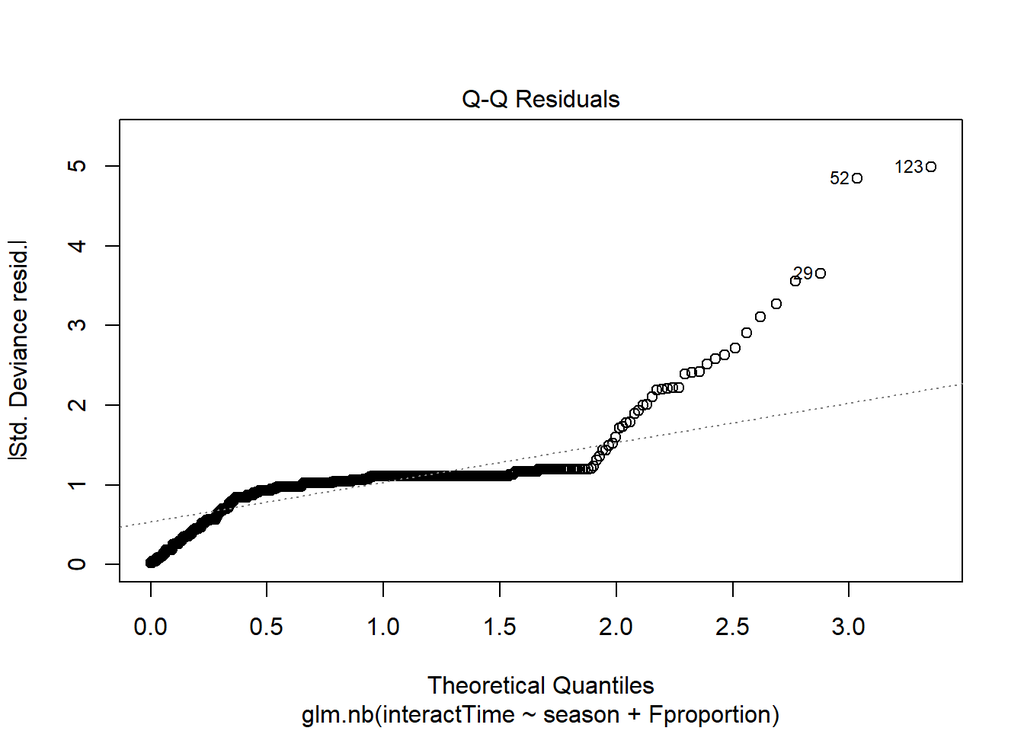

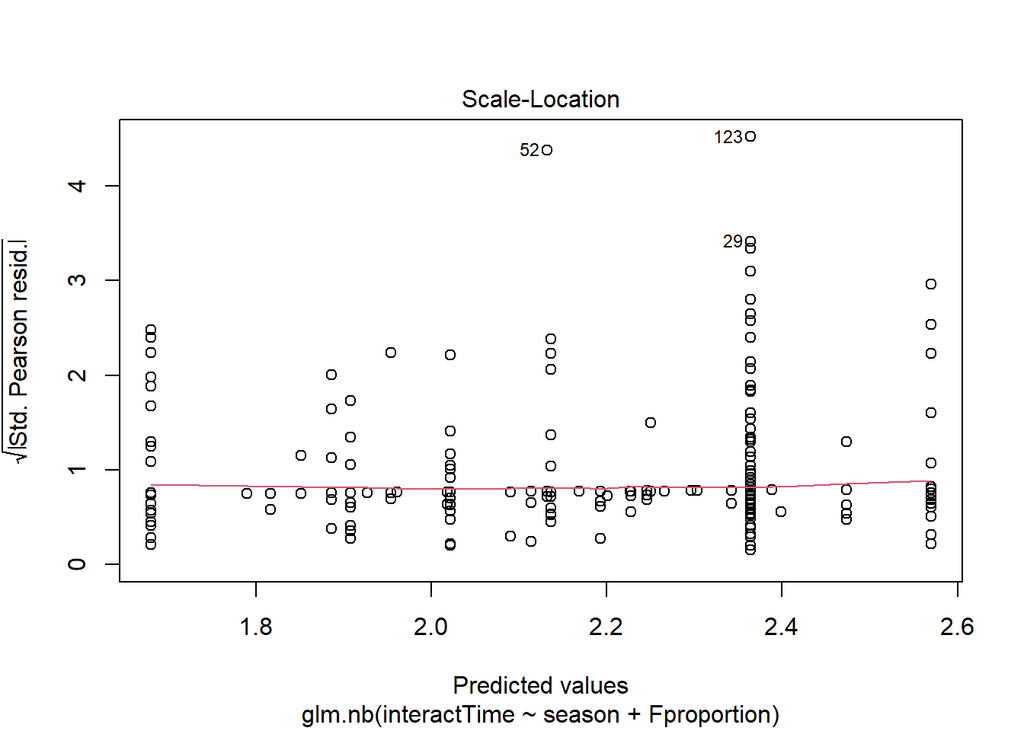

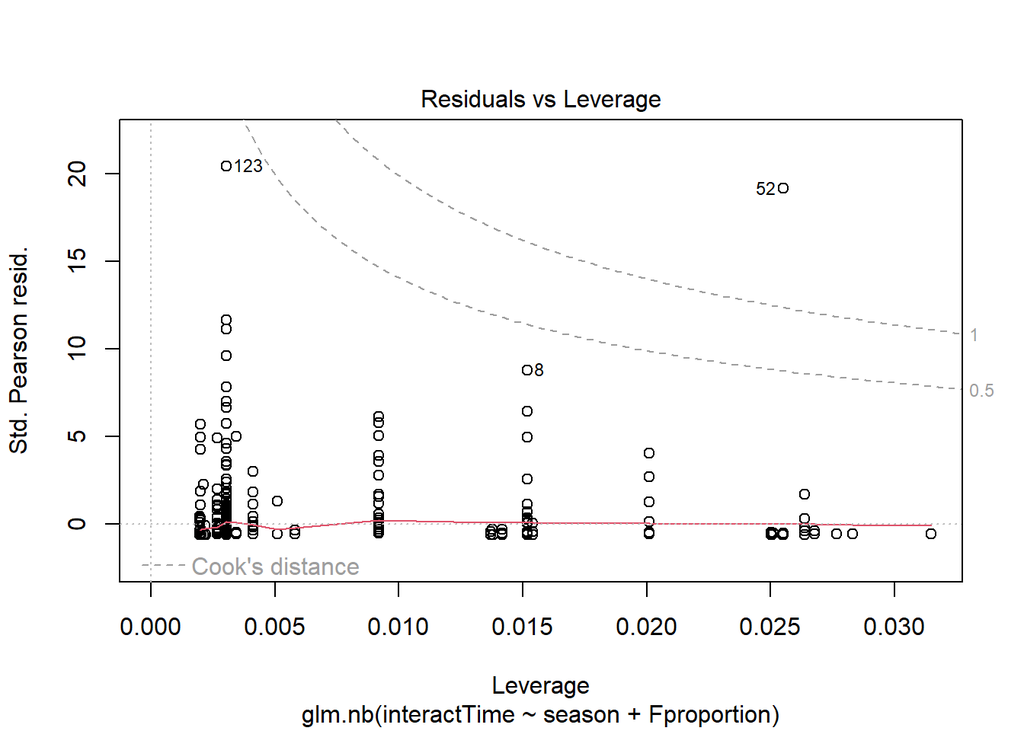

```r
plot(nbDF)
```

```r
library(MASS)
gammaDF <- glm(interactTime ~ season + Fproportion, family = Gamma(link = log),
               data = ColNcOnly)
summary(gammaDF)
```

```
##
## Call:
## glm(formula = interactTime ~ season + Fproportion, family = Gamma(link = log),
##     data = ColNcOnly)
##
## Coefficients:
##              Estimate Std. Error t value Pr(>|t|)
## (Intercept)    1.6865     0.2618   6.443 2.36e-10 ***
## seasonSummer   0.2050     0.3395   0.604    0.546
## seasonWinter   0.1122     0.4452   0.252    0.801
## Fproportion    0.6755     0.3214   2.101    0.036 *
## ---
## Signif. codes:  0 '***' 0.001 '**' 0.01 '*' 0.05 '.' 0.1 ' ' 1
##
## (Dispersion parameter for Gamma family taken to be 7.352325)
##
##     Null deviance: 1660.7  on 622  degrees of freedom
## Residual deviance: 1621.2  on 619  degrees of freedom
## AIC: 3738
##
## Number of Fisher Scoring iterations: 9
```

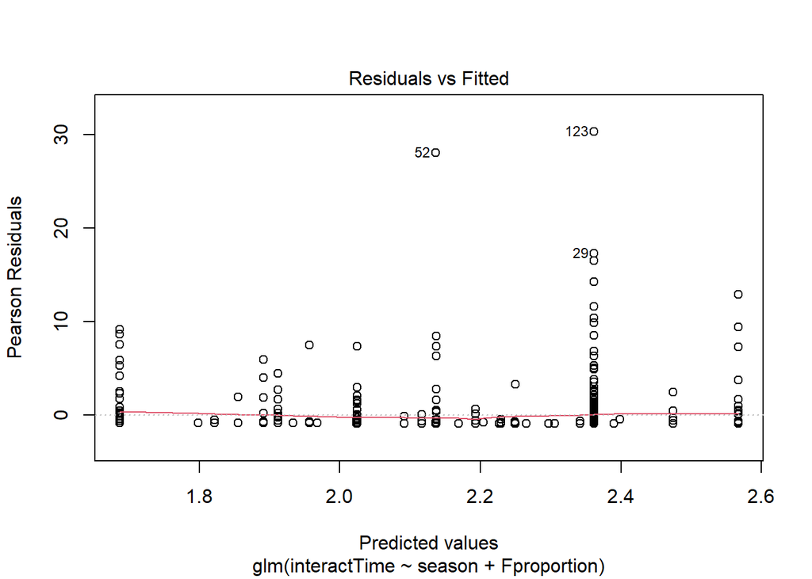

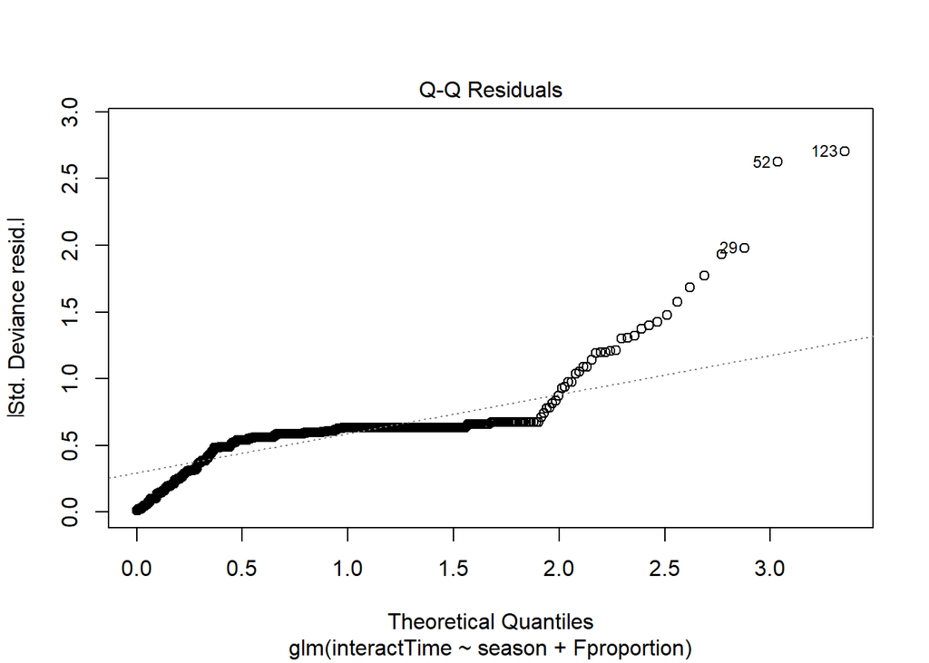

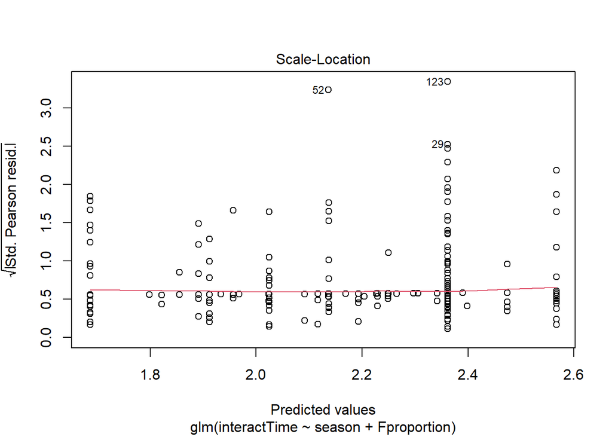

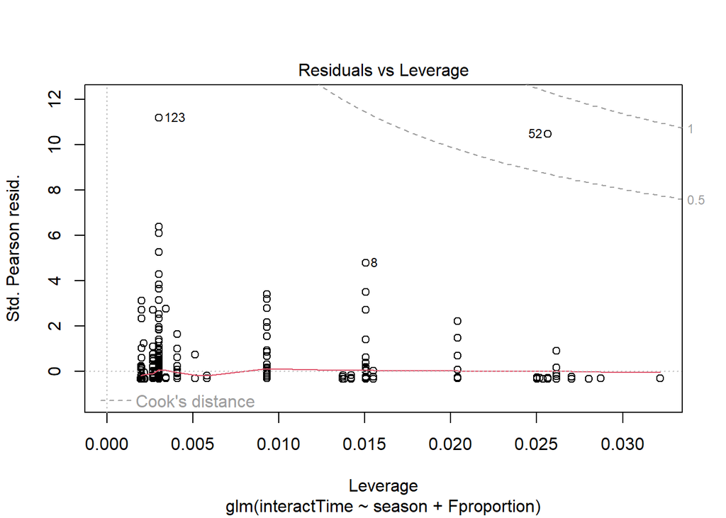

```r
plot(gammaDF)
```

```r
gammaDF2 <- glm(interactTime ~ Fproportion, family = Gamma(link = log),
               data = ColNcOnly)
summary(gammaDF2)
```

```
##
## Call:
## glm(formula = interactTime ~ Fproportion, family = Gamma(link = log),
##     data = ColNcOnly)
##
## Coefficients:
##             Estimate Std. Error t value Pr(>|t|)
## (Intercept)   1.7242     0.2578   6.689 5.01e-11 ***
## Fproportion   0.6700     0.3244   2.066   0.0393 *
## ---
## Signif. codes:  0 '***' 0.001 '**' 0.01 '*' 0.05 '.' 0.1 ' ' 1
##
## (Dispersion parameter for Gamma family taken to be 7.494441)
##
##     Null deviance: 1660.7  on 622  degrees of freedom
## Residual deviance: 1624.3  on 621  degrees of freedom
## AIC: 3735.6
##
## Number of Fisher Scoring iterations: 8
```

```r
gammaDF3 <- glm(interactTime ~ season , family = Gamma(link = log),
               data = ColNcOnly)
summary(gammaDF3)
```

```
##
## Call:
## glm(formula = interactTime ~ season, family = Gamma(link = log),
##     data = ColNcOnly)
##
## Coefficients:
##               Estimate Std. Error t value Pr(>|t|)
## (Intercept)  2.2080589  0.1276054  17.304   <2e-16 ***
## seasonSummer 0.2107860  0.3606134   0.585    0.559
## seasonWinter 0.0002156  0.4731735   0.000    1.000
## ---
## Signif. codes:  0 '***' 0.001 '**' 0.01 '*' 0.05 '.' 0.1 ' ' 1
##
## (Dispersion parameter for Gamma family taken to be 8.3044)
##
##     Null deviance: 1660.7  on 622  degrees of freedom
## Residual deviance: 1657.7  on 620  degrees of freedom
## AIC: 3754.4
##
## Number of Fisher Scoring iterations: 8
```

```r
#negative binomial
nb2 <- glm.nb(interactTime ~ Fproportion,
               data = ColNcOnly)
summary(nb2)
```

```
##
## Call:
## glm.nb(formula = interactTime ~ Fproportion, data = ColNcOnly,
##     init.theta = 0.4747736205, link = log)
##
## Coefficients:
##             Estimate Std. Error z value Pr(>|z|)
## (Intercept)   1.7182     0.1417  12.127  < 2e-16 ***
## Fproportion   0.6778     0.1776   3.816 0.000136 ***
## ---
## Signif. codes:  0 '***' 0.001 '**' 0.01 '*' 0.05 '.' 0.1 ' ' 1
##
## (Dispersion parameter for Negative Binomial(0.4748) family taken to be 1)
##
##     Null deviance: 719.71  on 622  degrees of freedom
## Residual deviance: 703.15  on 621  degrees of freedom
## AIC: 3828.7
##
## Number of Fisher Scoring iterations: 1
##
##
##               Theta:  0.4748
##           Std. Err.:  0.0242
##
##  2 x log-likelihood:  -3822.7240
```

```r
nb3 <- glm.nb(interactTime ~ season ,
               data = ColNcOnly)
summary(nb3)
```

```
##
## Call:
## glm.nb(formula = interactTime ~ season, data = ColNcOnly, init.theta = 0.4660019901,
##     link = log)
##
## Coefficients:
##               Estimate Std. Error z value Pr(>|z|)
## (Intercept)  2.2080589  0.0665071  33.200   <2e-16 ***
## seasonSummer 0.2107860  0.1871865   1.126    0.260
## seasonWinter 0.0002155  0.2466136   0.001    0.999
## ---
## Signif. codes:  0 '***' 0.001 '**' 0.01 '*' 0.05 '.' 0.1 ' ' 1
##
## (Dispersion parameter for Negative Binomial(0.466) family taken to be 1)
##
##     Null deviance: 707.50  on 622  degrees of freedom
## Residual deviance: 706.15  on 620  degrees of freedom
## AIC: 3845.8
##
## Number of Fisher Scoring iterations: 1
##
##
##               Theta:  0.4660
##           Std. Err.:  0.0236
##
##  2 x log-likelihood:  -3837.7780
```

```r
#test with anova's log likleyhood
anova(gammaDF2, gammaDF, test = "Chisq")
```

```
## Analysis of Deviance Table
##
## Model 1: interactTime ~ Fproportion
## Model 2: interactTime ~ season + Fproportion
##   Resid. Df Resid. Dev Df Deviance Pr(>Chi)
## 1       621     1624.3
## 2       619     1621.2  2   3.0938   0.8103
```

```r
anova(gammaDF3, gammaDF, test = "Chisq")
```

```
## Analysis of Deviance Table
##
## Model 1: interactTime ~ season
## Model 2: interactTime ~ season + Fproportion
##   Resid. Df Resid. Dev Df Deviance Pr(>Chi)
## 1       620     1657.7
## 2       619     1621.2  1   36.493  0.02589 *
## ---
## Signif. codes:  0 '***' 0.001 '**' 0.01 '*' 0.05 '.' 0.1 ' ' 1
```

```r
logLik(gammaDF)
```

```
## 'log Lik.' -1864.018 (df=5)
```

```r
logLik(gammaDF2)
```

```
## 'log Lik.' -1864.805 (df=3)
```

```r
logLik(gammaDF3)
```

```
## 'log Lik.' -1873.219 (df=4)
```

```r
AIC(nbDF, gammaDF, gammaDF2, gammaDF3)
```

```
##          df      AIC
## nbDF      5 3831.323
## gammaDF   5 3738.036
## gammaDF2  3 3735.609
## gammaDF3  4 3754.439
```

```r
library(performance)
check_overdispersion(gammaDF)#this test still shows a lot of ovedispersion despite already using negative binomial
```

```
## # Overdispersion test
##
##  dispersion ratio =   3.866
##           p-value = < 0.001
```

```
## Overdispersion detected.
```

```r
check_overdispersion(nbDF)#this test still shows a lot of ovedispersion despite already using negative binomial
```

```
## # Overdispersion test
##
##  dispersion ratio =   3.578
##           p-value = < 0.001
```

```
## Overdispersion detected.
```

Taking into account the severe amount of 1 second interactions

```r
#does the proportion of female deer influence the chance of an interaction lasting longer than 1 second?
ColNcOnly$longInteract <- (ColNcOnly$interactTime > 1)
ColNcOnly$longInteract <- as.numeric(ColNcOnly$longInteract)

longBin <- glm(longInteract ~ season + Fproportion, family = binomial, data = ColNcOnly)
summary(longBin)
```

```
##
## Call:
## glm(formula = longInteract ~ season + Fproportion, family = binomial,
##     data = ColNcOnly)
##
## Coefficients:
##               Estimate Std. Error z value Pr(>|z|)
## (Intercept)  -0.494510   0.198973  -2.485   0.0129 *
## seasonSummer  0.008305   0.255920   0.032   0.9741
## seasonWinter -0.424644   0.356754  -1.190   0.2339
## Fproportion   0.100266   0.244022   0.411   0.6812
## ---
## Signif. codes:  0 '***' 0.001 '**' 0.01 '*' 0.05 '.' 0.1 ' ' 1
##
## (Dispersion parameter for binomial family taken to be 1)
##
##     Null deviance: 833.29  on 622  degrees of freedom
## Residual deviance: 831.61  on 619  degrees of freedom
## AIC: 839.61
##
## Number of Fisher Scoring iterations: 4
```

```r
check_overdispersion(longBin)
```

```
## # Overdispersion test
##
##  dispersion ratio = 1.002
##           p-value = 0.952
```

```
## No overdispersion detected.
```

```r
#does the proportion of female deer increase the leangth of interactions which are already over 1 second?
#only look at interactions over 1 second
longOnly <- subset(ColNcOnly, interactTime > 1)
longModel <- glm.nb(interactTime ~ season + Fproportion, data = longOnly)
summary(longModel)
```

```
##
## Call:
## glm.nb(formula = interactTime ~ season + Fproportion, data = longOnly,
##     init.theta = 0.7932620889, link = log)
##
## Coefficients:
##              Estimate Std. Error z value Pr(>|z|)
## (Intercept)    2.5343     0.1677  15.109  < 2e-16 ***
## seasonSummer   0.2170     0.2273   0.955 0.339586
## seasonWinter   0.3847     0.3381   1.138 0.255172
## Fproportion    0.6824     0.1992   3.426 0.000612 ***
## ---
## Signif. codes:  0 '***' 0.001 '**' 0.01 '*' 0.05 '.' 0.1 ' ' 1
##
## (Dispersion parameter for Negative Binomial(0.7933) family taken to be 1)
##
##     Null deviance: 289.34  on 242  degrees of freedom
## Residual deviance: 276.56  on 239  degrees of freedom
## AIC: 1993.6
##
## Number of Fisher Scoring iterations: 1
##
##
##               Theta:  0.7933
##           Std. Err.:  0.0655
##
##  2 x log-likelihood:  -1983.5560
```

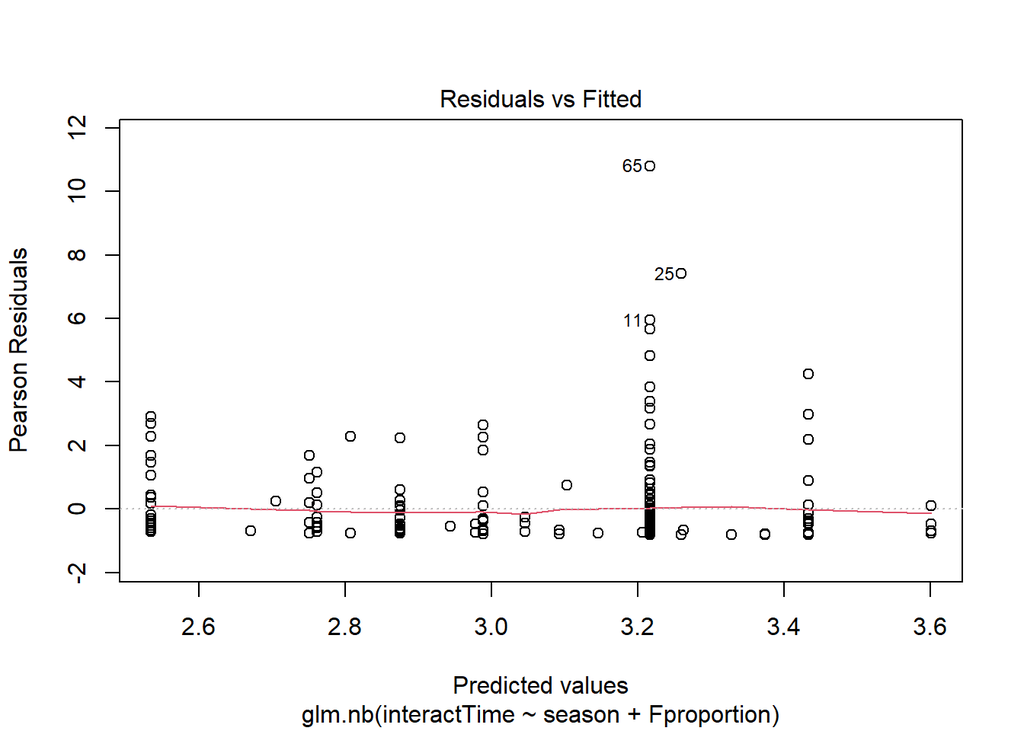

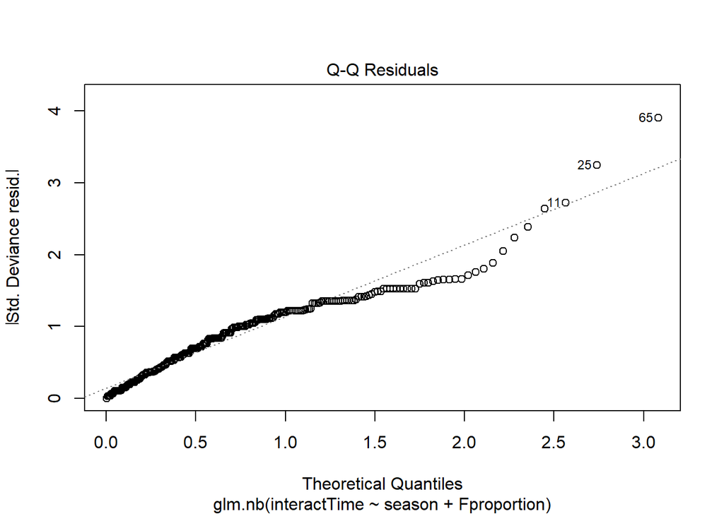

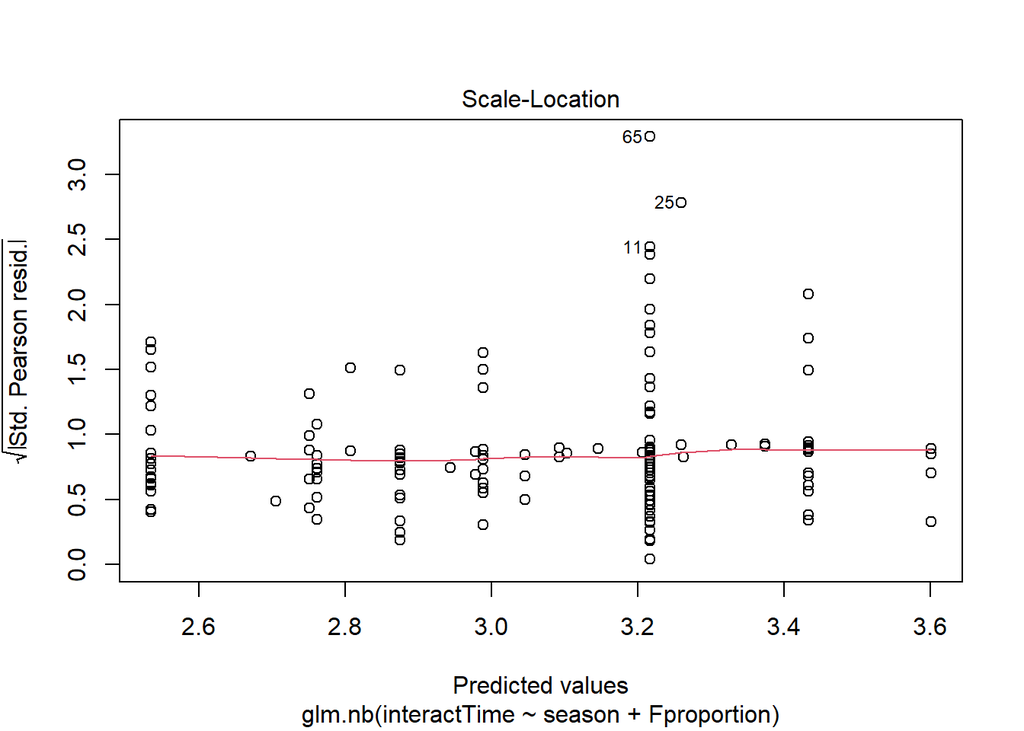

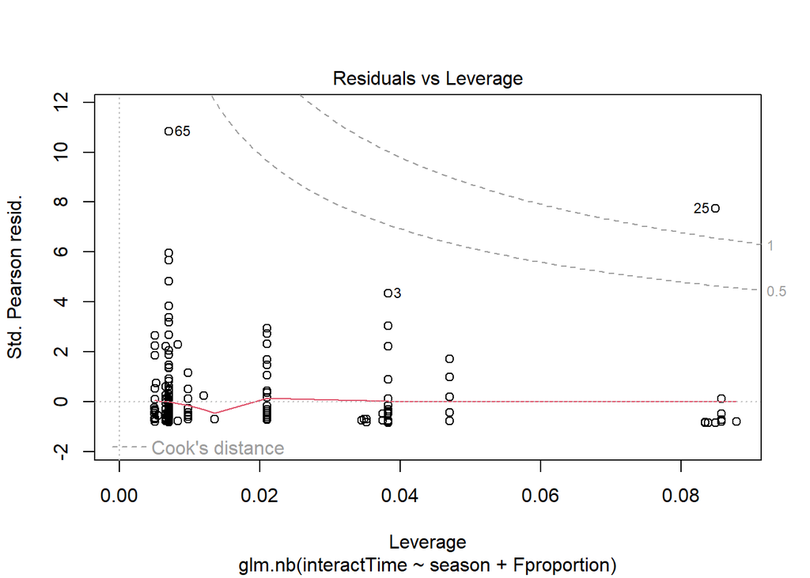

```r
plot(longModel)
```

```r
check_overdispersion(longModel)
```

```
## # Overdispersion test
##
##  dispersion ratio =   2.205
##           p-value = < 0.001
```

```
## Overdispersion detected.
```

```r
#    Null deviance: 289.22  on 242  degrees of freedom
#Residual deviance: 276.58  on 239  degrees of freedom
#AIC: 1993.7


#gamma, slightly better
gamIntOnlyDF <- subset(ColNcOnly, interactTime > 1)
gamIntOnly <- glm(interactTime ~ season + Fproportion, family = Gamma(link = log), data = longOnly)
summary(gamIntOnly)
```

```
##
## Call:
## glm(formula = interactTime ~ season + Fproportion, family = Gamma(link = log),
##     data = longOnly)
##
## Coefficients:
##              Estimate Std. Error t value Pr(>|t|)
## (Intercept)    2.5353     0.2356  10.762   <2e-16 ***
## seasonSummer   0.2155     0.3224   0.668   0.5046
## seasonWinter   0.3871     0.4813   0.804   0.4221
## Fproportion    0.6812     0.2806   2.428   0.0159 *
## ---
## Signif. codes:  0 '***' 0.001 '**' 0.01 '*' 0.05 '.' 0.1 ' ' 1
##
## (Dispersion parameter for Gamma family taken to be 2.624342)
##
##     Null deviance: 386.77  on 242  degrees of freedom
## Residual deviance: 370.04  on 239  degrees of freedom
## AIC: 1984.5
##
## Number of Fisher Scoring iterations: 9
```

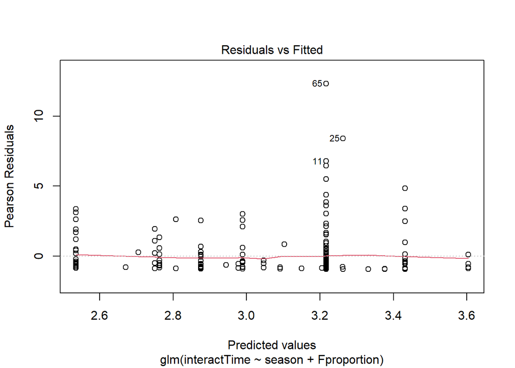

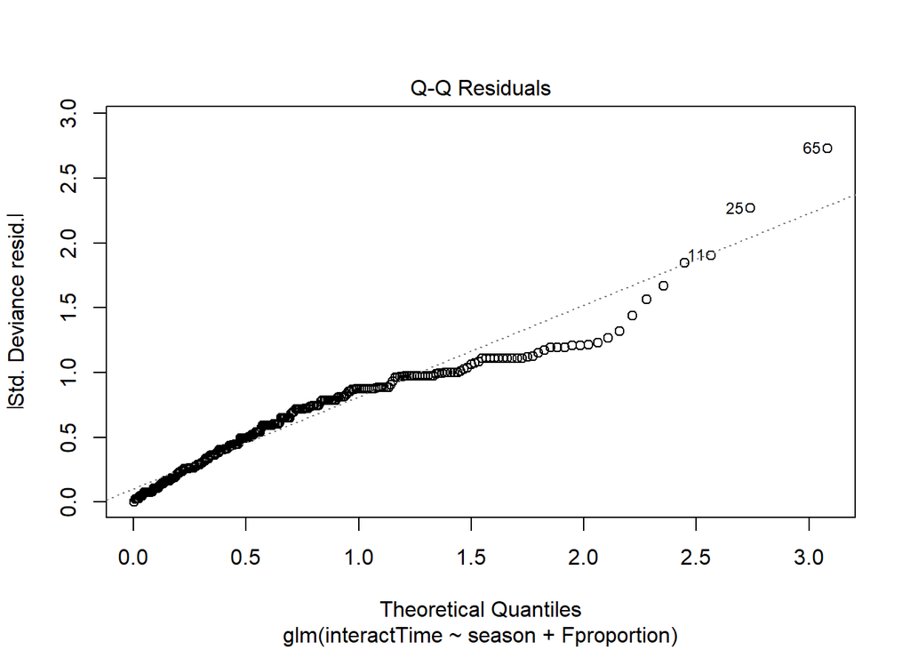

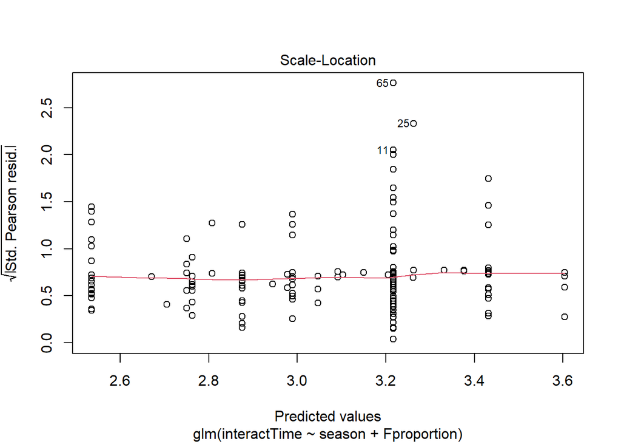

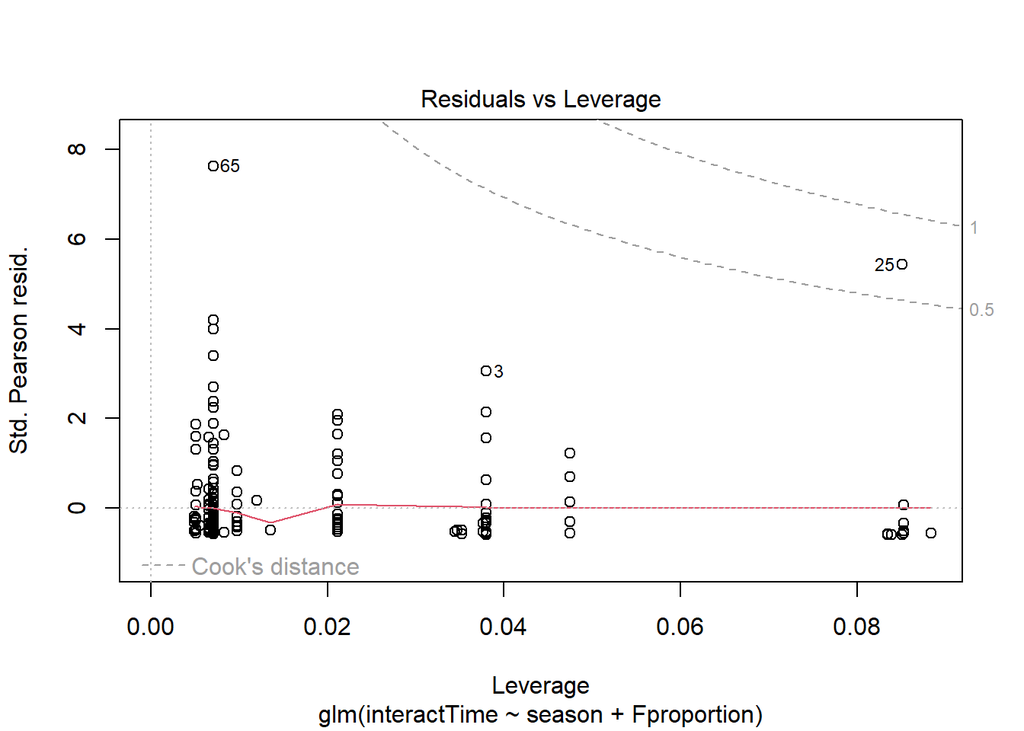

```r
plot(gamIntOnly)
```

```r
check_overdispersion(gamIntOnly)
```

```
## # Overdispersion test
##
##  dispersion ratio =   2.237
##           p-value = < 0.001
```

```
## Overdispersion detected.
```

```r
check_overdispersion(longModel)
```

```
## # Overdispersion test
##
##  dispersion ratio =   2.205
##           p-value = < 0.001
```

```
## Overdispersion detected.
```

```r
#    Null deviance: 386.77  on 242  degrees of freedom
#Residual deviance: 370.04  on 239  degrees of freedom
#AIC: 1984.5
```

https://bhaskarvk.github.io/user2017.geodataviz/notebooks/03-Interactive-Maps.nb.html#using_leaflet https://rstudio.github.io/leaflet/articles/popups.html https://r-graph-gallery.com/package/leaflet.html

```r
library(ggspatial)
library(ggmap)
library(leaflet)
library(htmltools)

#convert to dataframe and rename
ColCol <- data.frame(lng = c(CC$longitude), lat = c(CC$latitude))
COlColNcNt <- data.frame(lng = c(CCNcNt$longitude), lat = c(CCNcNt$latitude))
ColColNcT <- data.frame(lng = c(CCNcT$longitude), lat = c(CCNcT$latitude))
ColNcT <- data.frame(lng = c(CNcT$longitude), lat = c(CNcT$latitude))
ColNcNt <- data.frame(lng = c(CNcNt$longitude), lat = c(CNcNt$latitude))

#make a frequency column per location
COlColNcNt <- COlColNcNt%>% count(lng, lat, name = "freq")
ColCol <- ColCol %>% count(lng, lat, name = "freq")
ColNcNt <- ColNcNt%>% count(lng, lat, name = "freq")
ColNcT <- ColNcT%>% count(lng, lat, name = "freq")
ColColNcT <- ColColNcT %>% count(lng, lat, name = "freq")

#combine all the ones that are Collared + No collar interactions
ColNoColFull <- intervalDistinct3 %>% filter(interaction != 3)
ColNoColFull <- data.frame(lng = c(ColNoColFull$longitude), lat = c(ColNoColFull$latitude))
ColNoColFreq <- ColNoColFull %>% count(lng, lat, name = "freq")
```

Find areas with high amounts of Collared and Non-collared interaction

```r
pal <- colorNumeric(palette = c("lightpink", "maroon", "red"),
                    domain = ColNoColFreq$freq)
ColNoCol_map <- leaflet() %>%
  setView(lat = 40.588176, lng = -74.141917, zoom=13.49) %>%
  addTiles(group="OSM") %>%
  addProviderTiles(providers$CartoDB.DarkMatter, group="Dark") %>%
  addProviderTiles(providers$CartoDB.Positron, group="Light") %>%
  addLayersControl(baseGroups=c('OSM','Dark','Light')) %>%
  addCircleMarkers(data = ColNoColFreq, color = ~pal(ColNoColFreq$freq), popup = ~htmlEscape(ColNoColFreq$freq), opacity = 0.5)%>%
  addLegend("bottomright", pal = pal, values = ColNoColFreq$freq, opacity = 1)
```

```
## Assuming "lng" and "lat" are longitude and latitude, respectively
```

```r
ColNoCol_map
```

[interactive chart not shown]

Day vs Night

```r
colNoColTime <- intervalDistinct3 %>% filter(interaction != 3)
HourOfday <- colNoColTime %>% mutate(start_time = as.POSIXct(startTime), hour = as.numeric(format(start_time, "%H")), period = ifelse(hour > 6 & hour <18, "Day", "Night"))

Day <- HourOfday %>% filter(period == "Day")
Night <- HourOfday %>% filter(period == "Night")


DayDF <- data.frame(lng = c(Day$longitude), lat = c(Day$latitude))
DayFreq <- DayDF %>% count(lng, lat, name = "freq")

nightDF <- data.frame(lng = c(Night$longitude), lat = c(Night$latitude))
nightFreq <- nightDF %>% count(lng, lat, name = "freq")

############################################################################################################

#Day = red
colors <- colorNumeric(palette = c("lightpink", "maroon", "red3"),
                    domain = DayFreq$freq)
DayFreq_map <- leaflet() %>%
  setView(lat = 40.588176, lng = -74.141917, zoom=13.49) %>%
  addTiles(group="OSM") %>%
  addProviderTiles(providers$CartoDB.DarkMatter, group="Dark") %>%
  addProviderTiles(providers$CartoDB.Positron, group="Light") %>%
  addLayersControl(baseGroups=c('OSM','Dark','Light')) %>%
  addCircleMarkers(data = DayFreq, color = ~colors(DayFreq$freq), popup = ~htmlEscape(DayFreq$freq), opacity = 0.7)%>%
  addLegend("bottomright", pal = colors, values = DayFreq$freq, opacity = 1)
```

```
## Assuming "lng" and "lat" are longitude and latitude, respectively
```

```r
DayFreq_map
```

[interactive chart not shown]

Night is blue

```r
colors2 <- colorNumeric(palette = c("lightblue", "blue", "navy"),
                    domain = nightFreq$freq)
nightFreq_map <- leaflet() %>%
  setView(lat = 40.588176, lng = -74.141917, zoom=13.49) %>%
  addTiles(group="OSM") %>%
  addProviderTiles(providers$CartoDB.DarkMatter, group="Dark") %>%
  addProviderTiles(providers$CartoDB.Positron, group="Light") %>%
  addLayersControl(baseGroups=c('OSM','Dark','Light')) %>%
  addCircleMarkers(data = nightFreq, color = ~colors2(nightFreq$freq), popup = ~htmlEscape(nightFreq$freq), opacity = 0.85)%>%
  addLegend("bottomright", pal = colors2, values = nightFreq$freq, opacity = 1)
```

```
## Assuming "lng" and "lat" are longitude and latitude, respectively
```

```r
nightFreq_map
```

[interactive chart not shown]

```r
library(leaflet.extras)
library(sf)
```

```r
library(mapview)
library(viridis)
library(rcrimeanalysis)
```

https://cran.r-project.org/web/packages/rcrimeanalysis/vignettes/rcrimeanalysis.html kernel density estimator KDE

```r
ColNoColKDE <-  ColNoColFull %>% rename(longitude = lng, latitude = lat)

kde_map(ColNoColKDE, pts = FALSE)
```

[interactive chart not shown]

KDE by season(does not really work because the cameras are also stagnant and have repeat interactions no matter the season)

```r
ColNoColSeasons <- intervalDistinct3 %>% filter(interaction != 3)

Winter <- ColNoColSeasons %>% filter(season == "Winter")
Summer <- ColNoColSeasons %>% filter(season == "Summer")
Spring <- ColNoColSeasons %>% filter(season == "Spring")


WinterKDE <-  ColNoColFull %>% rename(longitude = lng, latitude = lat)
SummerKDE <-  ColNoColFull %>% rename(longitude = lng, latitude = lat)
SpringKDE <-  ColNoColFull %>% rename(longitude = lng, latitude = lat)

kde_map(WinterKDE, pts = F)
```

[interactive chart not shown]

```r
kde_map(SummerKDE, pts = F)
```

[interactive chart not shown]

```r
kde_map(SpringKDE, pts = F)
```

[interactive chart not shown]

https://rpubs.com/nomarpicasso/1158007 Heat map, doesnt give any new information its basically just blurring the existing data points

Map for Collared + Collared

```r
pal1 <- colorNumeric(palette = c("turquoise3", "blue", "navy"),
                    domain = ColCol$freq)

ColCol_map <- leaflet() %>%
  setView(lat = 40.588176, lng = -74.141917, zoom=13.25) %>%
  addTiles(group="OSM") %>%
  addProviderTiles(providers$CartoDB.DarkMatter, group="Dark") %>%
  addProviderTiles(providers$CartoDB.Positron, group="Light") %>%
  addLayersControl(baseGroups=c('OSM','Dark','Light')) %>%
  addCircleMarkers(data = ColCol, color = ~pal1(ColCol$freq), popup = ~htmlEscape(ColCol$freq)) %>%
  addLegend("bottomright", pal = pal1, values = ColCol$freq, opacity = 1)
```

```
## Assuming "lng" and "lat" are longitude and latitude, respectively
```

```r
ColCol_map
```

[interactive chart not shown]

Map for Collared + Collared + No Collar&No tag

```r
pal2 <- colorNumeric(palette = c("turquoise3", "blue", "navy"),
                    domain = COlColNcNt$freq)

COlColNcNt_map <- leaflet() %>%
  setView(lat = 40.588176, lng = -74.141917, zoom=13) %>%
  addTiles(group="OSM") %>%
  addProviderTiles(providers$CartoDB.DarkMatter, group="Dark") %>%
  addProviderTiles(providers$CartoDB.Positron, group="Light") %>%
  addLayersControl(baseGroups=c('OSM','Dark','Light')) %>%
  addCircleMarkers(data = COlColNcNt, color = ~pal2(COlColNcNt$freq), popup = ~htmlEscape(COlColNcNt$freq)) %>%
  addLegend("bottomright", pal = pal2, values = COlColNcNt$freq, opacity = 1)
```

```
## Assuming "lng" and "lat" are longitude and latitude, respectively
```

```r
COlColNcNt_map
```

[interactive chart not shown]

Map for Collared + Collared + No Collar&Tagged

```r
pal3 <- colorNumeric(palette = c("turquoise3", "blue", "navy"),
                     domain = ColColNcT$freq)

ColColNcT_map <- leaflet() %>%
  setView(lat = 40.588176, lng = -74.141917, zoom=13.25) %>%
  addTiles(group="OSM") %>%
  addProviderTiles(providers$CartoDB.DarkMatter, group="Dark") %>%
  addProviderTiles(providers$CartoDB.Positron, group="Light") %>%
  addLayersControl(baseGroups=c('OSM','Dark','Light')) %>%
  addCircleMarkers(data = ColColNcT, color = ~pal3(ColColNcT$freq), popup = ~htmlEscape(ColColNcT$freq)) %>%
  addLegend("bottomright", pal = pal3, values = ColColNcT$freq, opacity = 1)
```

```
## Assuming "lng" and "lat" are longitude and latitude, respectively
```

```r
ColColNcT_map
```

[interactive chart not shown]

Map for Collared + No Collar&Tagged

```r
pal4 <- colorNumeric(palette = c("turquoise3", "blue", "navy"),
                     domain = ColNcT$freq)

ColNcT_map <- leaflet() %>%
  setView(lat = 40.588176, lng = -74.141917, zoom=13.25) %>%
  addTiles(group="OSM") %>%
  addProviderTiles(providers$CartoDB.DarkMatter, group="Dark") %>%
  addProviderTiles(providers$CartoDB.Positron, group="Light") %>%
  addLayersControl(baseGroups=c('OSM','Dark','Light')) %>%
  addCircleMarkers(data = ColNcT, color = ~pal4(ColNcT$freq), popup = ~htmlEscape(ColNcT$freq)) %>%
  addLegend("bottomright", pal = pal4, values = ColNcT$freq, opacity = 1)
```

```
## Assuming "lng" and "lat" are longitude and latitude, respectively
```

```r
ColNcT_map
```

[interactive chart not shown]

Map for Collared + No Collar&No Tag

```r
pal5 <- colorNumeric(palette = c("turquoise3", "blue", "navy"),
                     domain = ColNcNt$freq)

ColNcNt_map <- leaflet() %>%
  setView(lat = 40.588176, lng = -74.141917, zoom=13.25) %>%
  addTiles(group="OSM") %>%
  addProviderTiles(providers$CartoDB.DarkMatter, group="Dark") %>%
  addProviderTiles(providers$CartoDB.Positron, group="Light") %>%
  addLayersControl(baseGroups=c('OSM','Dark','Light')) %>%
  addCircleMarkers(data = ColNcNt, color = ~pal5(ColNcNt$freq), popup = ~htmlEscape(ColNcNt$freq))  %>%
  addLegend("bottomright", pal = pal5, values = ColNcNt$freq, opacity = 1)
```

```
## Assuming "lng" and "lat" are longitude and latitude, respectively
```

```r
ColNcNt_map
```

[interactive chart not shown]